# ILoReg Package Manual

Edited: October 23, 2019

# Introduction to the method

ILoReg (abbr. for **I**terative **Lo**gistic **Reg**ression) is an R package for high-precision cell type identification from single-cell RNA-seq (scRNA-seq) data. High-precision refers to the ability of ILoReg to identify subpopulations with subtle transcriptomic differences. In our study ([Article title](https://gitlab.utu.fi/pajosm/iloreg)), we showed that ILoReg was able to identify, by both unsupervised clustering and visually, immune cell types that other scRNA-seq data analysis pipelines were not able to find. Moreover, ILoReg can identify subpopulations that are differentiable by only a single gene.

The figure below depicts the workflows of ILoReg and a feature selection -based pipeline, which is commonly used by many cell type identification methods, e.g. Seurat.

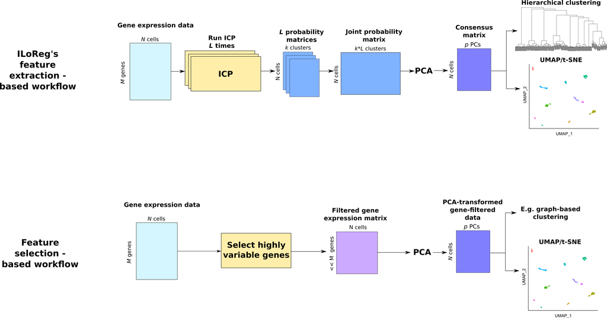

*Figure: Analysis workflows of ILoReg and a feature-selection based approach*

Unlike most scRNA-seq data analysis pipelines, ILoReg does not reduce the dimensionality of the gene expression matrix by feature selection. Instead, it performs probabilistic feature extraction, in which the Iterative Clustering Projection (ICP) clustering algorithm is run *L* times, which yields *L* *k*-dimensional probability matrices that contain the new features. ICP is a novel clustering algorithm that iteratively seeks a clustering of size *k* that maximizes the adjusted Rand index (ARI) between the clustering $C$ and its projection $C'$ by L1-regularized logistic regression:
$$\displaystyle \arg \max_C ARI(C,C')$$
The *L* probability matrices are then merged and transformed by the principal component analysis (PCA) into a lower dimension *p*. The second and final clustering step is performed using hierarhical clustering by the Ward’s method, from which the user can efficiently (~1 s with 3,000 cells) select a clustering of size *K*. Two-dimensional visualization is supported using two popular nonlinear dimensionality reduction methods: *t*-Distributed Stochastic Neighbor Embedding (t-SNE) and Uniform Manifold Approximation and Projection (UMAP).

# Installation

```r
library(devtools)

creds = git2r::cred_ssh_key("~/../.ssh/id_rsa.pub",
                            "~/../.ssh/id_rsa")
devtools::install_git("gitlab@gitlab.utu.fi:pajosm/iloreg.git",
                      credentials = creds)
```

# Example: Peripheral Blood Mononuclear Cells

In the following, we go through the different steps of ILoReg’s workflow and demonstrate it using a Peripheral Blood Mononuclear Cell (PBMC) dataset. The dataset (pbmc3k) can be downloaded from the following link: [GitHub](https://support.10xgenomics.com/single-cell-gene-expression/datasets)

### Load and Normalize a Dataset

To load and normalize the dataset, we use the Read10X and LogNormalize functions from Seurat R package. Currently, ILoReg R package does not have its own functions for normalizing scRNA-seq data. Therefore, the user must rely on other R packages to perform this step.

```r
data <- Seurat::LogNormalize(Seurat::Read10X("D:/10x_data/pbmc3k/filtered_gene_bc_matrices_GRCh37.p13/hg19/"),verbose = FALSE)
```

### Setup the iloreg R Object

The only required input for ILoReg is a normalized gene expression matrix with genes/features in rows and cells/samples in columns. The input can be of class *matrix*, *data.frame* or *dgCMatrix* and the matrix is then transformed into a sparse object of class *dgCMatrix*. **Please note that the method has been designed to work with sparse data, i.e. with lots of zero values. If for example the features of your dataset have been standardized, the method is likely to work much slower and require more RAM.**

```r
library(ILoReg)
library(cowplot)
# Create iloreg object.
iloreg_object <- CreateILoRegObject(normalized.data = data)
```

```
Data already of class 'dgCMatrix'
Removing non-expressing genes
16944 / 32738  left
```

### Run ICP clustering algorithm *L* times

Next comes by far the most computationally demanding part of the pipeline, in which *L* ICP solutions are computed with different random seeds. This step lasted ~2 hr with three threads on a laptop.

In the following, we give a brief summary of the parameters.

```r
# Run ICP L times. This is by far the slowest step of the workflow and parallel processing can be used to greatly speed it up.
tictoc::tic()
iloreg_object <- RunParallelICP(iloreg_object,threads = 3,L = 200,k = 15,C = 0.3,r = 5,d = 0.3,type = "L1",seed = 1)
```

### Quality control

Next, we consider two quality control measures of ICP that can aid detecting issues with the ICP analysis.

First, the terminal projection accuracy that denotes the adjusted Rand index (ARI) between the clustering and its logistic regression projection at the final epoch (iteration) of ICP. Projection accuracy 1 would mean the classifier was able to predict the cluster identity of all cells correctly. Higher accuracy can be achieved using lower values of $k$, $C$ and higher values of $d$ and $r$.

Second, the average pairwise ARI that measures how similar the different ICP runs are on average respect to each other. Higher $d$ leads to lower average pairwise ARI and smaller $k$ to higher average pairwise ARI. The relation of $C$ and $r$ with the average pairwise ARI is not as unambiguous as with the projection accuracy.

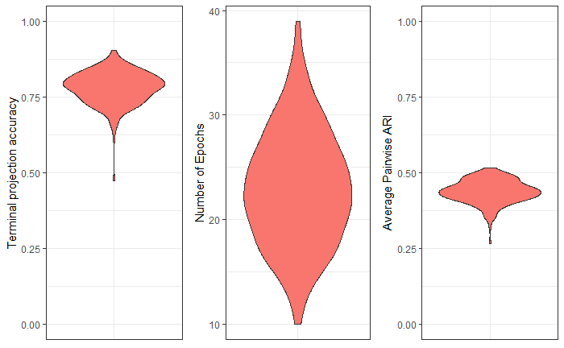

```r
# Draw violin plots of the terminal clustering projection accuracy, the number of epochs and the average pairwise ARI.
# Each data point represents a ICP run.
VisualizeQC(iloreg_object,return.plot = F)
```